# Analisis Deret Waktu IHSG dengan Model ARIMA dan Intervensi

Laporan Praktikum Metode Peramalan

Fatikha Naila Nur Sasabilah

2026-04-28

# 1 PENDAHULUAN

Pada penelitian ini dilakukan analisis deret waktu terhadap data Indeks Harga Saham Gabungan (IHSG) dengan tujuan untuk memperoleh model yang sesuai serta melakukan peramalan nilai IHSG pada periode mendatang. Analisis dilakukan menggunakan metode Autoregressive Integrated Moving Average (ARIMA) yang meliputi beberapa tahapan, yaitu eksplorasi data, uji stasioneritas, identifikasi model, pendugaan parameter, pengujian asumsi, pemilihan model terbaik, evaluasi kemampuan prediksi, serta peramalan.

Selain itu, penelitian ini juga mempertimbangkan adanya pengaruh faktor eksternal melalui pemodelan intervensi, yaitu peristiwa pengesahan RUU TNI pada tanggal 20 Maret 2025, untuk mengetahui apakah kejadian tersebut memberikan dampak terhadap pergerakan IHSG. Hasil dari seluruh tahapan analisis ini diharapkan dapat memberikan gambaran yang lebih jelas mengenai pola pergerakan IHSG serta menghasilkan model yang optimal untuk keperluan peramalan.

# 2 TAHAPAN ANALISIS DATA IHSG

Pada bagian ini dilakukan serangkaian tahapan analisis terhadap data Indeks Harga Saham Gabungan (IHSG) menggunakan metode deret waktu. Tahapan analisis dilakukan secara sistematis.

Data yang digunakan terdiri dari variabel tanggal dan harga penutup IHSG.

## 2.1 Eksplorasi Data

Pada tahap awal dilakukan eksplorasi data untuk mengetahui karakteristik dan pola pergerakan data IHSG.

```r
# mengetahui karakteristik data
str(data)
```

```
## tibble [311 × 2] (S3: tbl_df/tbl/data.frame)
##  $ Tanggal            : POSIXct[1:311], format: "2023-12-12" "2023-12-13" ...
##  $ Harga Saham Penutup: num [1:311] 7125 7075 7176 7191 7120 ...
```

```r
head(data)
```

```
## # A tibble: 6 × 2
##   Tanggal             `Harga Saham Penutup`
##   <dttm>                              <dbl>
## 1 2023-12-12 00:00:00                 7125.
## 2 2023-12-13 00:00:00                 7075.
## 3 2023-12-14 00:00:00                 7176.
## 4 2023-12-15 00:00:00                 7191.
## 5 2023-12-18 00:00:00                 7120.
## 6 2023-12-19 00:00:00                 7188.
```

```r
# ubah tanggal
data$Tanggal = as.Date(data$Tanggal)

# Ubah ke time series
ihsg_ts = ts(data$`Harga Saham Penutup`)
```

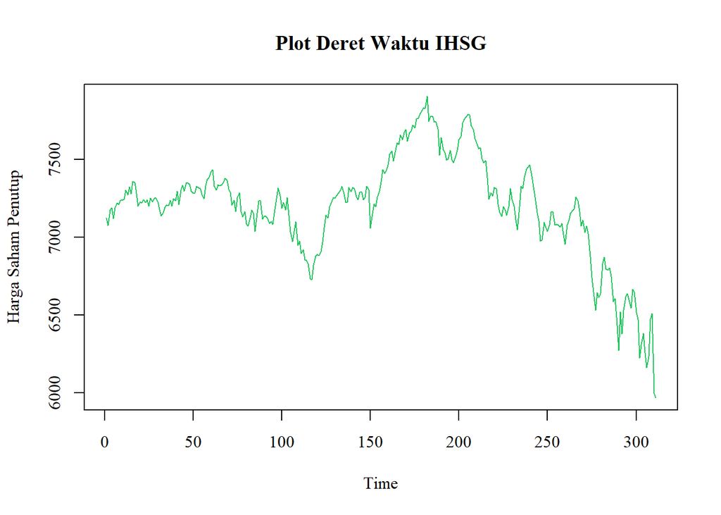

```r
# Plot deret waktu
windowsFonts(Times=windowsFont("TT Times New Roman"))
plot(ihsg_ts,
     main = "Plot Deret Waktu IHSG",
     ylab = "Harga Saham Penutup",
     col = "#22c55e",
     family = "Times",
     font.main = 2,
     cex.main = 1.2,
     cex.lab = 1
)
```

Berdasarkan plot deret waktu di atas, terlihat bahwa data IHSG menunjukkan pola yang tidak konstan. Data mengalami fluktuasi dari waktu ke waktu.

```r
# Summary
summary(ihsg_ts)
```

```
##    Min. 1st Qu.  Median    Mean 3rd Qu.    Max.
##    5968    7084    7234    7197    7339    7905
```

```r
# Deteksi outlier
outlier_result = tsoutliers(ihsg_ts)
outlier_result
```

```
## $index
## integer(0)
##
## $replacements
## numeric(0)
```

Hasil statistik deskriptif menunjukkan bahwa nilai minimum sebesar 5968, maksimum sebesar 7905, dan rata-rata sebesar 7197. Selain itu, hasil deteksi outlier menunjukkan bahwa tidak terdapat outlier pada data IHSG, sehingga tidak diperlukan penanganan khusus terhadap data.

## 2.2 Uji Stasioneritas

Uji stasioneritas dilakukan untuk mengetahui apakah data deret waktu IHSG memiliki rata-rata yang konstan dari waktu ke waktu. Pengujian dilakukan menggunakan uji Augmented Dickey-Fuller (ADF).

```r
adf.test(ihsg_ts)
```

```
##
##  Augmented Dickey-Fuller Test
##
## data:  ihsg_ts
## Dickey-Fuller = -0.59149, Lag order = 6, p-value = 0.9773
## alternative hypothesis: stationary
```

Hasil uji ADF menunjukkan bahwa nilai p-value lebih besar dari taraf signifikan (α = 0,05). Dengan demikian, dapat disimpulkan bahwa data belum stasioner, yaitu data mengandung tren dan perlu dilakukan transformasi. Untuk mengatasi hal tersebut, dilakukan proses differencing orde satu.

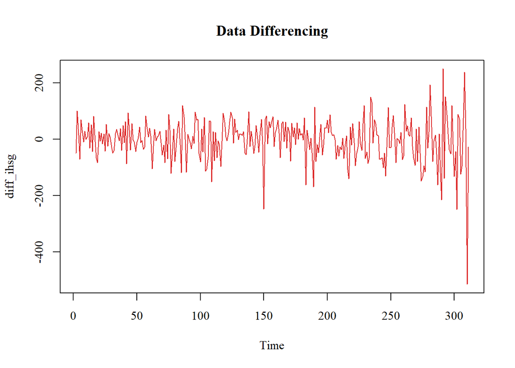

```r
# differencing
diff_ihsg = diff(ihsg_ts)

# Plot setelah differencing
plot(diff_ihsg, main="Data Differencing", col="#dc2626", family = "Times",
     font.main = 2,
     cex.main = 1.2,
     cex.lab = 1
)
```

Plot menunjukkan bahwa data hasil differencing berfluktuasi di sekitar nilai rata-rata yang relatif konstan dan tidak menunjukkan pola tren yang jelas.

Selanjutnya, dilakukan kembali uji ADF terhadap data hasil differencing.

```r
# Uji lagi
adf.test(diff_ihsg)
```

```
##
##  Augmented Dickey-Fuller Test
##
## data:  diff_ihsg
## Dickey-Fuller = -7.703, Lag order = 6, p-value = 0.01
## alternative hypothesis: stationary
```

Hasil pengujian menunjukkan bahwa nilai p-value lebih kecil dari taraf signifikan (α = 0,05), sehingga data telah stasioner dalam rata-rata. Dengan demikian, dapat disimpulkan bahwa data IHSG telah memenuhi asumsi stasioneritas setelah dilakukan differencing orde satu (d = 1), sehingga siap untuk tahap identifikasi model ARIMA.

## 2.3 Identifikasi Model

Identifikasi model dilakukan menggunakan plot Autocorrelation Function (ACF) dan Partial Autocorrelation Function (PACF).

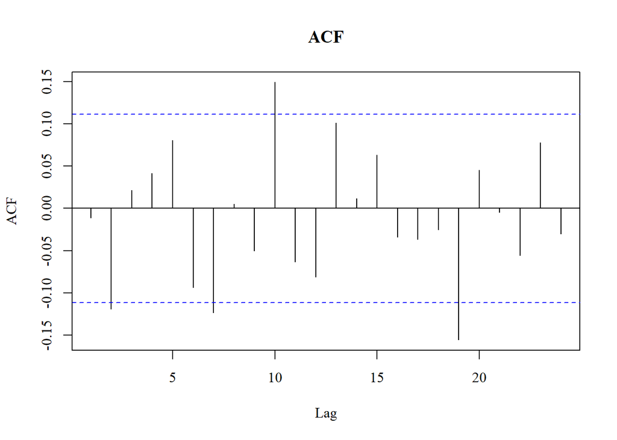

```r
# ACF dan PACF
acf(diff_ihsg, main="ACF", family = "Times",
    font.main = 2,
    cex.main = 1.2,
    cex.lab = 1)
```

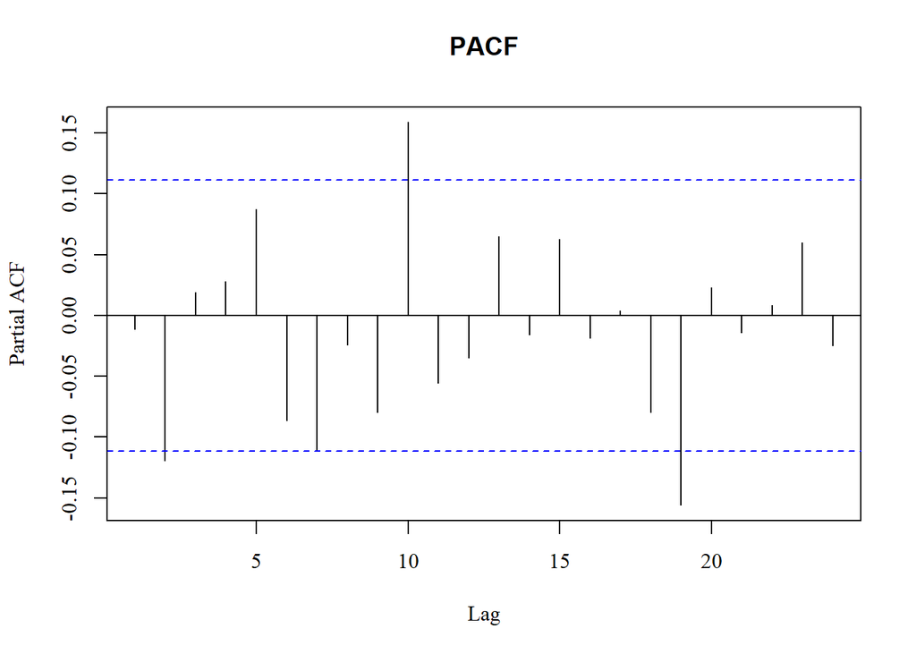

```r
pacf(diff_ihsg, main="PACF", family = "Times",
     font.main = 2,
     cex.main = 1.2,
     cex.lab = 1)
```

Berdasarkan pola tersebut, diperoleh kandidat model sebagai berikut:

Model utama: - ARIMA(0,1,0)

- ARIMA(0,1,1)
- ARIMA(1,1,0)
- ARIMA(1,1,1)

Model eksplorasi: - ARIMA(2,1,1)

- ARIMA(2,1,2)
- ARIMA(2,1,3)

Dengan demikian, model-model tersebut akan digunakan pada tahap pendugaan parameter.

## 2.4 Pendugaan Parameter dan Uji Signifikansi

Pendugaan parameter dilakukan untuk setiap model kandidat menggunakan metode MLE.

```r
# 5. Pendugaan Parameter
# Model kandidat utama
model1 = Arima(ihsg_ts, order=c(0,1,0))
model2 = Arima(ihsg_ts, order=c(0,1,1))
model3 = Arima(ihsg_ts, order=c(1,1,0))
model4 = Arima(ihsg_ts, order= c(1,1,1))
# Model kandidat eksplorasi
model5 = Arima(ihsg_ts, order = c(2,1,1))
model6 = Arima(ihsg_ts, order = c(2,1,2))
model7 = Arima(ihsg_ts, order = c(2,1,3))

# Menampilkan koefisien model
coeftest(model2)
```

```
##
## z test of coefficients:
##
##      Estimate Std. Error z value Pr(>|z|)
## ma1 -0.011455   0.064824 -0.1767   0.8597
```

```r
coeftest(model3)
```

```
##
## z test of coefficients:
##
##      Estimate Std. Error z value Pr(>|z|)
## ar1 -0.008768   0.056757 -0.1545   0.8772
```

```r
coeftest(model4)
```

```
##
## z test of coefficients:
##
##     Estimate Std. Error z value Pr(>|z|)
## ar1 -0.65269    0.23546 -2.7719 0.005572 **
## ma1  0.70318    0.21897  3.2113 0.001321 **
## ---
## Signif. codes:  0 '***' 0.001 '**' 0.01 '*' 0.05 '.' 0.1 ' ' 1
```

```r
coeftest(model5)
```

```
##
## z test of coefficients:
##
##      Estimate Std. Error z value Pr(>|z|)
## ar1 -0.147313   0.444728 -0.3312  0.74046
## ar2 -0.140323   0.061346 -2.2874  0.02217 *
## ma1  0.138888   0.448742  0.3095  0.75694
## ---
## Signif. codes:  0 '***' 0.001 '**' 0.01 '*' 0.05 '.' 0.1 ' ' 1
```

```r
coeftest(model6)
```

```
##
## z test of coefficients:
##
##      Estimate Std. Error z value  Pr(>|z|)
## ar1  0.851020   0.026792  31.764 < 2.2e-16 ***
## ar2 -0.913559   0.026406 -34.597 < 2.2e-16 ***
## ma1 -0.961102   0.015634 -61.475 < 2.2e-16 ***
## ma2  0.999830   0.028508  35.072 < 2.2e-16 ***
## ---
## Signif. codes:  0 '***' 0.001 '**' 0.01 '*' 0.05 '.' 0.1 ' ' 1
```

```r
coeftest(model7)
```

```
##
## z test of coefficients:
##
##      Estimate Std. Error  z value  Pr(>|z|)
## ar1  0.727909   0.097866   7.4378 1.024e-13 ***
## ar2 -0.846749   0.063558 -13.3225 < 2.2e-16 ***
## ma1 -0.756141   0.111491  -6.7821 1.185e-11 ***
## ma2  0.782298   0.106608   7.3381 2.167e-13 ***
## ma3  0.125005   0.067060   1.8641   0.06231 .
## ---
## Signif. codes:  0 '***' 0.001 '**' 0.01 '*' 0.05 '.' 0.1 ' ' 1
```

Hasil estimasi menunjukkan bahwa:

- Model ARIMA(0,1,0) tidak memiliki parameter yang diestimasi, sehingga tidak dilakukan uji signifikansi.
- Model ARIMA(0,1,1) dan ARIMA(1,1,0) memiliki parameter tidak signifikan.
- Model ARIMA(1,1,1) memiliki parameter yang signifikan.
- Model ARIMA(2,1,1) memiliki sebagian parameter yang signifikan.
- Model ARIMA(2,1,2) memiliki seluruh parameter signifikan.
- Model ARIMA(2,1,3) memiliki parameter yang signifikan, namun terdapat satu parameter yang tidak signifikan.

Dengan demikian, model ARIMA(2,1,2) menjadi kandidat kuat untuk tahap selanjutnya.

## 2.5 Pengujian Asumsi

Pengujian asumsi dilakukan untuk memastikan model memenuhi asumsi dasar.

1. Uji Autokorelasi (Ljung-Box)

```r
Box.test(model6$residuals, type="Ljung")
```

```
##
##  Box-Ljung test
##
## data:  model6$residuals
## X-squared = 1.2034, df = 1, p-value = 0.2726
```

Nilai p-value sebesar 0.2726 (> 0,05), sehingga residual tidak mengandung autokorelasi.

2. Uji Normalitas (Shapiro-Wilk)

```r
shapiro.test(model6$residuals)
```

```
##
##  Shapiro-Wilk normality test
##
## data:  model6$residuals
## W = 0.94029, p-value = 6.999e-10
```

Nilai p-value sebesar 6.999e-10 (< 0,05), sehingga residual tidak berdistribusi normal.

3. Diagnostik Model

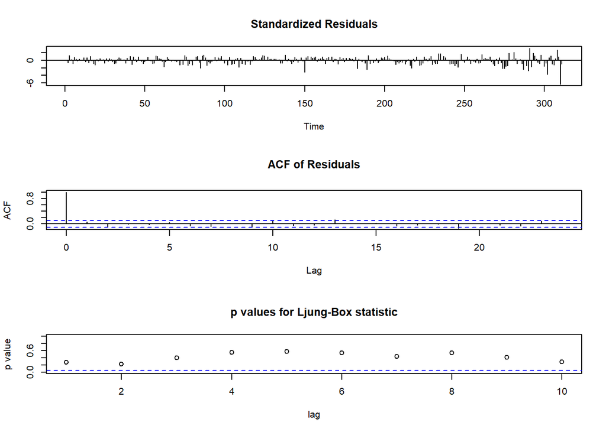

```r
tsdiag(model6)
```

Berdasarkan plot diagnostik, tidak terlihat pola tertentu pada residual, sehingga memperkuat bahwa residual sudah bersifat acak (white noise).

## 2.6 Pemilihan Model Terbaik

Pemilihan model dilakukan menggunakan kriteria AIC dan BIC.

```r
# 7. Pemilihan Model Terbaik
AIC(model1, model2, model3, model4, model5, model6, model7)
```

```
##        df      AIC
## model1  1 3558.256
## model2  2 3560.225
## model3  2 3560.232
## model4  3 3560.951
## model5  4 3559.009
## model6  5 3548.942
## model7  6 3548.707
```

```r
BIC(model1, model2, model3, model4, model5, model6, model7)
```

```
##        df      BIC
## model1  1 3561.993
## model2  2 3567.698
## model3  2 3567.705
## model4  3 3572.161
## model5  4 3573.956
## model6  5 3567.625
## model7  6 3571.126
```

## 2.7 Evaluasi Prediksi Model

Evaluasi dilakukan untuk mengukur kemampuan model dalam memprediksi data.

```r
# 8. Evaluasi prediksi
# Prediksi in-sample
pred1 = fitted(model1)
pred2 = fitted(model2)
pred3 = fitted(model3)
pred4 = fitted(model4)
pred5 = fitted(model5)
pred6 = fitted(model6)
pred7 = fitted(model7)

# Samakan panjang data
actual = tail(ihsg_ts, length(pred1))

# hasil evaluasi
hasil_evaluasi = data.frame(
  Model = c("ARIMA(0,1,0)", "ARIMA(0,1,1)", "ARIMA(1,1,0)", "ARIMA(1,1,1)",
            "ARIMA(2,1,1)", "ARIMA(2,1,2)", "ARIMA(2,1,3)"),
  MAPE = c(MAPE(actual, pred1), MAPE(actual, pred2), MAPE(actual, pred3),
           MAPE(actual, pred4), MAPE(actual, pred5), MAPE(actual, pred6),
           MAPE(actual, pred7)),
  RMSE = c(RMSE(actual, pred1), RMSE(actual, pred2), RMSE(actual, pred3),
           RMSE(actual, pred4), RMSE(actual, pred5), RMSE(actual, pred6),
           RMSE(actual, pred7))
)

hasil_evaluasi
```

```
##          Model        MAPE     RMSE
## 1 ARIMA(0,1,0) 0.007642243 74.84075
## 2 ARIMA(0,1,1) 0.007643878 74.83697
## 3 ARIMA(1,1,0) 0.007643455 74.83786
## 4 ARIMA(1,1,1) 0.007645208 74.68237
## 5 ARIMA(2,1,1) 0.007631708 74.20530
## 6 ARIMA(2,1,2) 0.007428635 72.17782
## 7 ARIMA(2,1,3) 0.007508984 72.42847
```

Berdasarkan nilai MAPE dan RMSE, model ARIMA(2,1,2) memiliki nilai terkecil yaitu MAPE sebesar 0.00742863 dan RMSE = 72.17782.

Hal ini menunjukkan bahwa model memiliki tingkat kesalahan prediksi yang paling rendah. Dengan demikian, model ARIMA(2,1,2) memiliki performa prediksi terbaik.

## 2.8 Model Intervensi

Model intervensi digunakan untuk melihat pengaruh kejadian eksternal terhadap data IHSG. Variabel intervensi dibentuk berdasarkan peristiwa pengesahan RUU TNI pada tanggal 20 Maret 2025.

```r
# 9. Model intervensi
# Intervensi berdasarkan tanggal pengesahan RUU TNI (20 Maret 2025)
intervensi = ifelse(data$Tanggal >= as.Date("2025-03-20"), 1, 0)
length(intervensi) == length(ihsg_ts)
```

```
## [1] TRUE
```

```r
model_intervensi = Arima(ihsg_ts, order=c(2,1,2), xreg=intervensi)
summary(model_intervensi)
```

```
## Series: ihsg_ts
## Regression with ARIMA(2,1,2) errors
##
## Coefficients:
##          ar1      ar2      ma1    ma2     xreg
##       0.8517  -0.9136  -0.9612  1.000   8.6436
## s.e.  0.0273   0.0265   0.0158  0.029  72.1846
##
## sigma^2 = 5311:  log likelihood = -1769.46
## AIC=3550.93   AICc=3551.2   BIC=3573.35
##
## Training set error measures:
##                     ME     RMSE      MAE         MPE     MAPE    MASE
## Training set -3.798045 72.17243 52.55543 -0.06404425 0.745748 0.97014
##                    ACF1
## Training set 0.06167433
```

```r
# Uji asumsi model intervensi
Box.test(model_intervensi$residuals, type="Ljung")
```

```
##
##  Box-Ljung test
##
## data:  model_intervensi$residuals
## X-squared = 1.1944, df = 1, p-value = 0.2744
```

```r
shapiro.test(model_intervensi$residuals)
```

```
##
##  Shapiro-Wilk normality test
##
## data:  model_intervensi$residuals
## W = 0.93984, p-value = 6.271e-10
```

Hasil model menunjukkan bahwa model intervensi dapat dibentuk dengan baik tanpa adanya error, serta memiliki residual yang telah memenuhi asumsi nonautokorelasi (white noise).

```r
# Uji kebaikan model intervensi
hasil_aicbic = data.frame(
  Model = c("ARIMA(2,1,2)", "ARIMA(2,1,2) + Intervensi"),
  AIC = c(AIC(model6), AIC(model_intervensi)),
  BIC = c(BIC(model6), BIC(model_intervensi))
)

hasil_aicbic
```

```
##                       Model      AIC      BIC
## 1              ARIMA(2,1,2) 3548.942 3567.625
## 2 ARIMA(2,1,2) + Intervensi 3550.928 3573.347
```

Perbandingan AIC dan BIC menunjukkan bahwa model tanpa intervensi lebih baik. Dengan demikian, intervensi tidak berpengaruh terhadap IHSG.

## 2.9 Peramalan

Peramalan dilakukan untuk memprediksi nilai IHSG pada periode mendatang.

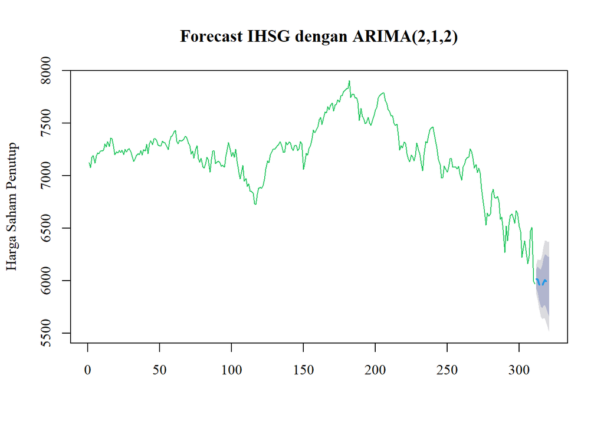

```r
# 10. peramalan
forecast = forecast(model6, h=10)
plot(forecast,
     main = "Forecast IHSG dengan ARIMA(2,1,2)",
     ylab = "Harga Saham Penutup",
     col = "#22c55e",
     flty = 2,
     shaded = TRUE,
     family = "Times",
     font.main = 2,
     cex.main = 1.2,
     cex.lab = 1)
```

```r
# Nilai prediksi
forecast
```

```
##     Point Forecast    Lo 80    Hi 80    Lo 95    Hi 95
## 312       6015.340 5921.817 6108.862 5872.309 6158.370
## 313       6012.982 5887.617 6138.347 5821.252 6204.712
## 314       5967.719 5817.657 6117.781 5738.219 6197.218
## 315       5931.353 5755.969 6106.737 5663.127 6199.579
## 316       5941.755 5740.471 6143.040 5633.917 6249.594
## 317       5983.830 5759.961 6207.700 5641.452 6326.209
## 318       6010.134 5768.844 6251.423 5641.113 6379.154
## 319       5994.081 5738.603 6249.558 5603.362 6384.799
## 320       5956.389 5686.803 6225.976 5544.092 6368.686
## 321       5938.979 5653.666 6224.291 5502.630 6375.327
```

```r
# Tingkat akurasi
akurasi = (1 - hasil_evaluasi$MAPE[6])*100
akurasi
```

```
## [1] 99.25714
```

Analisis & Interpretasi: Hasil peramalan menunjukkan bahwa IHSG cenderung bergerak relatif stabil dengan fluktuasi kecil di sekitar nilai tertentu. Interval kepercayaan menunjukkan bahwa ketidakpastian prediksi semakin besar seiring waktu. Model mampu mengikuti pola data historis dengan baik dan memberikan gambaran pergerakan IHSG di masa mendatang. Dengan demikian, model dapat digunakan untuk peramalan dengan tingkat akurasi 99,26%.

# 3 KESIMPULAN

Hasil evaluasi menunjukkan bahwa model memiliki tingkat akurasi yang sangat tinggi, yaitu sekitar 99,26%, sehingga model mampu merepresentasikan pola data IHSG dengan baik.

Selain itu, pemodelan intervensi yang dilakukan menunjukkan bahwa peristiwa pengesahan RUU TNI tidak memberikan pengaruh yang signifikan terhadap pergerakan IHSG dalam model yang digunakan. Hal ini mengindikasikan bahwa tidak semua kejadian eksternal secara langsung mempengaruhi pergerakan pasar saham atau pengaruhnya tidak tertangkap dalam periode pengamatan.

Dengan demikian, model ARIMA(2,1,2) dapat digunakan sebagai model yang cukup baik untuk melakukan peramalan IHSG pada periode mendatang.